# ABC101 synthetic review demonstration

Study data, descriptive displays, QC, and open gaps

Published

October 13, 2026

> **SYNTHETIC DATA — EDUCATIONAL REVIEW DEMONSTRATION.** ABC101 has no real participants, protocol, SAP, source CRFs, or clinical conclusions. The CSVs, Define-XML, displays, and checks below are not an FDA submission or a claim of CDISC conformance.

**Report version:** 1.0  
**Source snapshot:** current project outputs and documents, reviewed 2026-10-13  
**Purpose:** navigate the generated data and its descriptive safety displays, with their documented limitations.

## Study assumptions and scope

The versioned study-design assumptions define an illustrative type 2 diabetes study with **500 generated subjects** in three arms: Placebo, Drug 10 mg, and Drug 20 mg. The assumed study start of **2025-01-01** was selected for a retrospective standards-version exercise; it is not an actual protocol or consent date. Planned and actual arms match in this generated dataset. Each subject has one exposure interval from 2025-01-01 to 2025-03-26 inclusive, represented as one tablet once daily; the interval does not document dose-by-dose adherence or mg actually taken.

LB and VS have Baseline and Weeks 2, 4, 8, and 12. Baseline is selected by visit label. Baseline collection and first exposure share a date, but no times establish a predose measurement. All 500 generated subjects have `ITTFL=Y` and `SAFFL=Y` by project convention. Table 1 uses the planned arm; the safety displays use the actual arm. The cSDRG and ADRG give dataset-level navigation and traceability.

## Data flow and traceability

```
flowchart LR
  A[Generated raw CSVs] --> B[SDTM-like CSVs<br/>DM AE LB VS EX]
  B --> C[ADaM-like CSVs<br/>ADSL ADAE ADLB ADVS]
  C --> D[Tables 1–4<br/>Listing 1<br/>Figure 1]
  B --> E[SDTM QC]
  C --> F[ADaM QC]
  D --> G[Independent TLF QC]
  B --> H[CSV-linked Define-XML]
  C --> H
  H --> I[Limited conformance screening]
```

The five SDTM CSVs derive from generated raw demographics, adverse events, labs, vital signs, and exposure. The four ADaM CSVs use SDTM DM/EX for ADSL and SDTM AE/LB/VS plus ADSL for the record-level datasets. `USUBJID` links subjects. ADAE, ADLB, and ADVS retain source sequence values in `SRCSEQ`; ADLB/ADVS also identify their selected baseline row with `BLSEQ`. The SDTM specifications, ADaM specifications, and CSV-linked Define-XML metadata describe the mappings.

The analysis TEAE flag is `Y` when AE onset is from `TRTSDT` through 30 days after `TRTEDT`, inclusive; with current fixed dates, the window ends 2025-04-25. ADAE retains events outside the window. ADLB/ADVS use a single visit-based baseline per subject/test, then calculate postbaseline change and percent change. These rules are programming conventions for this synthetic example, not SAP decisions.

## Descriptive tables

The tables below are included directly from the corresponding generated Markdown displays. Their source CSVs and R programs are linked in the ADRG. Values are descriptive and have no clinical interpretation.

# Table 1. Demographic characteristics by planned treatment

Study ABC101; intent-to-treat population

| Characteristic | Statistic | Placebo | Drug 10 mg | Drug 20 mg | Overall |
| --- | --- | --- | --- | --- | --- |
| Subjects | N | 157 | 166 | 177 | 500 |
| Age (years) | n | 157 | 166 | 177 | 500 |
|  | Mean (SD) | 47.9 (17.8) | 49.0 (19.3) | 48.9 (19.4) | 48.6 (18.8) |
|  | Median | 47.0 | 50.0 | 50.0 | 49.5 |
|  | Min | 18.0 | 18.0 | 18.0 | 18.0 |
|  | Max | 79.0 | 80.0 | 80.0 | 80.0 |
| Sex | Female, n (%) | 76 (48.4%) | 82 (49.4%) | 81 (45.8%) | 239 (47.8%) |
|  | Male, n (%) | 81 (51.6%) | 84 (50.6%) | 96 (54.2%) | 261 (52.2%) |

Percentages use the number of subjects in each treatment column as the denominator. Age is summarized in years; SD is the sample standard deviation.

# Table 2. Treatment-emergent adverse events by actual treatment

Study ABC101; safety population

| Characteristic | Statistic | Placebo | Drug 10 mg | Drug 20 mg | Overall |
| --- | --- | --- | --- | --- | --- |
| Safety population | N | 157 | 166 | 177 | 500 |
| Subjects with any TEAE | n (%) | 101 (64.3%) | 100 (60.2%) | 108 (61.0%) | 309 (61.8%) |
| TEAE records | n | 149 | 158 | 166 | 473 |
| Subjects with serious TEAE | n (%) | 3 (1.9%) | 3 (1.8%) | 7 (4.0%) | 13 (2.6%) |
| Subjects with severe TEAE | n (%) | 4 (2.5%) | 11 (6.6%) | 7 (4.0%) | 22 (4.4%) |
| Event term |  |  |  |  |  |
| Injection Site Reaction | n (%) | 20 (12.7%) | 18 (10.8%) | 26 (14.7%) | 64 (12.8%) |
| Nausea | n (%) | 15 (9.6%) | 21 (12.7%) | 26 (14.7%) | 62 (12.4%) |
| Diarrhea | n (%) | 21 (13.4%) | 21 (12.7%) | 18 (10.2%) | 60 (12.0%) |
| Dizziness | n (%) | 21 (13.4%) | 18 (10.8%) | 19 (10.7%) | 58 (11.6%) |
| Fatigue | n (%) | 17 (10.8%) | 23 (13.9%) | 18 (10.2%) | 58 (11.6%) |
| Upper Respiratory Infection | n (%) | 21 (13.4%) | 16 (9.6%) | 19 (10.7%) | 56 (11.2%) |
| Abdominal Pain | n (%) | 16 (10.2%) | 13 (7.8%) | 21 (11.9%) | 50 (10.0%) |
| Headache | n (%) | 11 (7.0%) | 22 (13.3%) | 13 (7.3%) | 46 (9.2%) |

TEAE: event onset from treatment start through 30 days after treatment end, inclusive. Incidence is the number of distinct subjects with at least one qualifying event; percentages use the safety population N in the same treatment column. Subjects may appear in more than one event-term row. Serious and severe rows may overlap. Event-term labels come from the synthetic source data and are not externally coded.

# Table 3. Laboratory results and change from baseline by actual treatment

Study ABC101; safety population

| PARAMCD | Lab test | Unit | Visit | Visit number | Measure | Placebo n | Placebo Mean (SD) | Drug 10 mg n | Drug 10 mg Mean (SD) | Drug 20 mg n | Drug 20 mg Mean (SD) | Overall n | Overall Mean (SD) |
| --- | --- | --- | --- | --- | --- | --- | --- | --- | --- | --- | --- | --- | --- |
| ALT | Alanine Aminotransferase | U/L | Baseline | 1 | Observed value | 157 | 31.41 (9.32) | 166 | 29.80 (9.81) | 177 | 28.96 (10.63) | 500 | 30.01 (9.99) |
| ALT | Alanine Aminotransferase | U/L | Week 2 | 2 | Observed value | 157 | 29.88 (9.69) | 166 | 30.52 (10.49) | 177 | 29.08 (9.87) | 500 | 29.81 (10.02) |
| ALT | Alanine Aminotransferase | U/L | Week 2 | 2 | Change from baseline | 157 | -1.53 (12.31) | 166 | 0.72 (13.53) | 177 | 0.12 (14.46) | 500 | -0.20 (13.51) |
| ALT | Alanine Aminotransferase | U/L | Week 4 | 3 | Observed value | 157 | 29.44 (9.95) | 166 | 29.78 (9.91) | 177 | 29.17 (9.61) | 500 | 29.46 (9.80) |
| ALT | Alanine Aminotransferase | U/L | Week 4 | 3 | Change from baseline | 157 | -1.97 (13.56) | 166 | -0.02 (13.46) | 177 | 0.21 (14.20) | 500 | -0.55 (13.76) |
| ALT | Alanine Aminotransferase | U/L | Week 8 | 4 | Observed value | 157 | 30.47 (9.29) | 166 | 29.84 (9.32) | 177 | 30.39 (9.79) | 500 | 30.24 (9.46) |
| ALT | Alanine Aminotransferase | U/L | Week 8 | 4 | Change from baseline | 157 | -0.93 (13.16) | 166 | 0.04 (13.65) | 177 | 1.43 (13.66) | 500 | 0.23 (13.51) |
| ALT | Alanine Aminotransferase | U/L | Week 12 | 5 | Observed value | 157 | 29.56 (9.87) | 166 | 29.37 (9.46) | 177 | 29.37 (9.69) | 500 | 29.43 (9.65) |
| ALT | Alanine Aminotransferase | U/L | Week 12 | 5 | Change from baseline | 157 | -1.84 (13.64) | 166 | -0.44 (14.03) | 177 | 0.41 (14.22) | 500 | -0.58 (13.98) |
| AST | Aspartate Aminotransferase | U/L | Baseline | 1 | Observed value | 157 | 28.04 (7.92) | 166 | 27.98 (8.08) | 177 | 28.64 (7.40) | 500 | 28.23 (7.78) |
| AST | Aspartate Aminotransferase | U/L | Week 2 | 2 | Observed value | 157 | 28.28 (8.45) | 166 | 28.66 (8.13) | 177 | 28.67 (8.33) | 500 | 28.54 (8.29) |
| AST | Aspartate Aminotransferase | U/L | Week 2 | 2 | Change from baseline | 157 | 0.24 (11.03) | 166 | 0.68 (12.11) | 177 | 0.02 (10.51) | 500 | 0.31 (11.21) |
| AST | Aspartate Aminotransferase | U/L | Week 4 | 3 | Observed value | 157 | 27.52 (7.89) | 166 | 27.34 (8.34) | 177 | 28.62 (8.27) | 500 | 27.85 (8.18) |
| AST | Aspartate Aminotransferase | U/L | Week 4 | 3 | Change from baseline | 157 | -0.52 (11.23) | 166 | -0.64 (12.24) | 177 | -0.03 (11.43) | 500 | -0.39 (11.62) |
| AST | Aspartate Aminotransferase | U/L | Week 8 | 4 | Observed value | 157 | 29.42 (7.74) | 166 | 27.26 (8.27) | 177 | 28.15 (7.60) | 500 | 28.25 (7.91) |
| AST | Aspartate Aminotransferase | U/L | Week 8 | 4 | Change from baseline | 157 | 1.38 (10.43) | 166 | -0.72 (11.12) | 177 | -0.50 (10.14) | 500 | 0.02 (10.58) |
| AST | Aspartate Aminotransferase | U/L | Week 12 | 5 | Observed value | 157 | 28.55 (8.08) | 166 | 28.62 (8.26) | 177 | 28.45 (7.89) | 500 | 28.54 (8.06) |
| AST | Aspartate Aminotransferase | U/L | Week 12 | 5 | Change from baseline | 157 | 0.51 (11.46) | 166 | 0.64 (11.29) | 177 | -0.20 (10.38) | 500 | 0.30 (11.02) |
| CREAT | Creatinine | mg/dL | Baseline | 1 | Observed value | 157 | 0.89 (0.19) | 166 | 0.91 (0.20) | 177 | 0.90 (0.20) | 500 | 0.90 (0.20) |
| CREAT | Creatinine | mg/dL | Week 2 | 2 | Observed value | 157 | 0.93 (0.18) | 166 | 0.92 (0.19) | 177 | 0.87 (0.21) | 500 | 0.91 (0.20) |
| CREAT | Creatinine | mg/dL | Week 2 | 2 | Change from baseline | 157 | 0.03 (0.26) | 166 | 0.01 (0.27) | 177 | -0.03 (0.32) | 500 | 0.00 (0.28) |
| CREAT | Creatinine | mg/dL | Week 4 | 3 | Observed value | 157 | 0.90 (0.19) | 166 | 0.86 (0.21) | 177 | 0.89 (0.20) | 500 | 0.88 (0.20) |
| CREAT | Creatinine | mg/dL | Week 4 | 3 | Change from baseline | 157 | 0.01 (0.28) | 166 | -0.06 (0.29) | 177 | -0.01 (0.29) | 500 | -0.02 (0.29) |
| CREAT | Creatinine | mg/dL | Week 8 | 4 | Observed value | 157 | 0.91 (0.19) | 166 | 0.89 (0.20) | 177 | 0.88 (0.19) | 500 | 0.89 (0.19) |
| CREAT | Creatinine | mg/dL | Week 8 | 4 | Change from baseline | 157 | 0.02 (0.28) | 166 | -0.02 (0.28) | 177 | -0.02 (0.28) | 500 | -0.01 (0.28) |
| CREAT | Creatinine | mg/dL | Week 12 | 5 | Observed value | 157 | 0.91 (0.19) | 166 | 0.91 (0.19) | 177 | 0.91 (0.20) | 500 | 0.91 (0.19) |
| CREAT | Creatinine | mg/dL | Week 12 | 5 | Change from baseline | 157 | 0.02 (0.26) | 166 | 0.00 (0.28) | 177 | 0.01 (0.28) | 500 | 0.01 (0.27) |
| HGB | Hemoglobin | g/dL | Baseline | 1 | Observed value | 157 | 13.97 (1.51) | 166 | 14.00 (1.37) | 177 | 13.89 (1.44) | 500 | 13.95 (1.44) |
| HGB | Hemoglobin | g/dL | Week 2 | 2 | Observed value | 157 | 13.88 (1.47) | 166 | 13.95 (1.49) | 177 | 13.93 (1.37) | 500 | 13.92 (1.44) |
| HGB | Hemoglobin | g/dL | Week 2 | 2 | Change from baseline | 157 | -0.09 (2.02) | 166 | -0.05 (1.84) | 177 | 0.04 (1.98) | 500 | -0.03 (1.94) |
| HGB | Hemoglobin | g/dL | Week 4 | 3 | Observed value | 157 | 14.08 (1.54) | 166 | 14.08 (1.64) | 177 | 14.04 (1.69) | 500 | 14.06 (1.62) |
| HGB | Hemoglobin | g/dL | Week 4 | 3 | Change from baseline | 157 | 0.11 (2.14) | 166 | 0.07 (2.06) | 177 | 0.15 (2.19) | 500 | 0.11 (2.13) |
| HGB | Hemoglobin | g/dL | Week 8 | 4 | Observed value | 157 | 13.93 (1.56) | 166 | 13.85 (1.48) | 177 | 14.07 (1.52) | 500 | 13.95 (1.52) |
| HGB | Hemoglobin | g/dL | Week 8 | 4 | Change from baseline | 157 | -0.04 (2.22) | 166 | -0.15 (2.00) | 177 | 0.18 (2.06) | 500 | 0.00 (2.09) |
| HGB | Hemoglobin | g/dL | Week 12 | 5 | Observed value | 157 | 13.85 (1.38) | 166 | 14.10 (1.34) | 177 | 13.87 (1.51) | 500 | 13.94 (1.42) |
| HGB | Hemoglobin | g/dL | Week 12 | 5 | Change from baseline | 157 | -0.11 (2.07) | 166 | 0.10 (1.89) | 177 | -0.02 (2.06) | 500 | -0.01 (2.01) |

n is the number of distinct subjects with a nonmissing result for the measure. Mean (SD) uses the sample standard deviation and is displayed to two decimal places. Change from baseline is shown only at postbaseline visits.

# Table 4. Vital signs and change from baseline by actual treatment

Study ABC101; safety population

| PARAMCD | Vital-sign test | Unit | Visit | Visit number | Measure | Placebo n | Placebo Mean (SD) | Drug 10 mg n | Drug 10 mg Mean (SD) | Drug 20 mg n | Drug 20 mg Mean (SD) | Overall n | Overall Mean (SD) |
| --- | --- | --- | --- | --- | --- | --- | --- | --- | --- | --- | --- | --- | --- |
| SYSBP | Systolic Blood Pressure | mmHg | Baseline | 1 | Observed value | 157 | 128.11 (12.67) | 166 | 124.78 (12.39) | 177 | 125.11 (12.08) | 500 | 125.94 (12.43) |
| SYSBP | Systolic Blood Pressure | mmHg | Week 2 | 2 | Observed value | 157 | 125.26 (12.04) | 166 | 124.01 (11.90) | 177 | 125.38 (12.66) | 500 | 124.89 (12.21) |
| SYSBP | Systolic Blood Pressure | mmHg | Week 2 | 2 | Change from baseline | 157 | -2.85 (18.22) | 166 | -0.77 (16.72) | 177 | 0.27 (16.99) | 500 | -1.05 (17.31) |
| SYSBP | Systolic Blood Pressure | mmHg | Week 4 | 3 | Observed value | 157 | 124.36 (11.49) | 166 | 125.18 (12.81) | 177 | 124.33 (12.32) | 500 | 124.62 (12.21) |
| SYSBP | Systolic Blood Pressure | mmHg | Week 4 | 3 | Change from baseline | 157 | -3.75 (17.20) | 166 | 0.40 (18.12) | 177 | -0.79 (18.45) | 500 | -1.32 (18.00) |
| SYSBP | Systolic Blood Pressure | mmHg | Week 8 | 4 | Observed value | 157 | 124.89 (11.24) | 166 | 124.50 (11.71) | 177 | 125.66 (11.63) | 500 | 125.03 (11.52) |
| SYSBP | Systolic Blood Pressure | mmHg | Week 8 | 4 | Change from baseline | 157 | -3.22 (17.71) | 166 | -0.28 (17.23) | 177 | 0.54 (16.38) | 500 | -0.91 (17.13) |
| SYSBP | Systolic Blood Pressure | mmHg | Week 12 | 5 | Observed value | 157 | 127.27 (11.61) | 166 | 126.57 (11.21) | 177 | 123.59 (12.47) | 500 | 125.74 (11.88) |
| SYSBP | Systolic Blood Pressure | mmHg | Week 12 | 5 | Change from baseline | 157 | -0.83 (16.72) | 166 | 1.80 (16.28) | 177 | -1.52 (17.86) | 500 | -0.20 (17.02) |
| DIABP | Diastolic Blood Pressure | mmHg | Baseline | 1 | Observed value | 157 | 77.20 (7.82) | 166 | 76.80 (7.59) | 177 | 77.80 (7.47) | 500 | 77.28 (7.62) |
| DIABP | Diastolic Blood Pressure | mmHg | Week 2 | 2 | Observed value | 157 | 78.49 (7.81) | 166 | 78.11 (8.24) | 177 | 77.45 (7.92) | 500 | 78.00 (7.99) |
| DIABP | Diastolic Blood Pressure | mmHg | Week 2 | 2 | Change from baseline | 157 | 1.29 (10.74) | 166 | 1.31 (11.79) | 177 | -0.35 (10.03) | 500 | 0.72 (10.87) |
| DIABP | Diastolic Blood Pressure | mmHg | Week 4 | 3 | Observed value | 157 | 78.33 (8.59) | 166 | 78.40 (8.18) | 177 | 77.51 (7.79) | 500 | 78.06 (8.17) |
| DIABP | Diastolic Blood Pressure | mmHg | Week 4 | 3 | Change from baseline | 157 | 1.13 (11.67) | 166 | 1.60 (11.05) | 177 | -0.29 (10.26) | 500 | 0.78 (10.99) |
| DIABP | Diastolic Blood Pressure | mmHg | Week 8 | 4 | Observed value | 157 | 77.54 (8.46) | 166 | 78.80 (8.05) | 177 | 79.72 (8.50) | 500 | 78.73 (8.37) |
| DIABP | Diastolic Blood Pressure | mmHg | Week 8 | 4 | Change from baseline | 157 | 0.34 (10.71) | 166 | 2.00 (10.95) | 177 | 1.92 (11.17) | 500 | 1.45 (10.96) |
| DIABP | Diastolic Blood Pressure | mmHg | Week 12 | 5 | Observed value | 157 | 77.85 (8.66) | 166 | 77.40 (8.72) | 177 | 77.97 (7.65) | 500 | 77.74 (8.33) |
| DIABP | Diastolic Blood Pressure | mmHg | Week 12 | 5 | Change from baseline | 157 | 0.66 (11.45) | 166 | 0.60 (11.75) | 177 | 0.16 (9.62) | 500 | 0.46 (10.92) |
| PULSE | Pulse Rate | bpm | Baseline | 1 | Observed value | 157 | 71.58 (10.11) | 166 | 72.13 (10.14) | 177 | 72.54 (10.65) | 500 | 72.10 (10.30) |
| PULSE | Pulse Rate | bpm | Week 2 | 2 | Observed value | 157 | 74.07 (9.92) | 166 | 73.50 (10.21) | 177 | 71.33 (10.45) | 500 | 72.91 (10.26) |
| PULSE | Pulse Rate | bpm | Week 2 | 2 | Change from baseline | 157 | 2.49 (14.94) | 166 | 1.37 (14.18) | 177 | -1.21 (16.00) | 500 | 0.81 (15.14) |
| PULSE | Pulse Rate | bpm | Week 4 | 3 | Observed value | 157 | 71.79 (11.47) | 166 | 72.14 (11.35) | 177 | 71.82 (10.93) | 500 | 71.92 (11.22) |
| PULSE | Pulse Rate | bpm | Week 4 | 3 | Change from baseline | 157 | 0.21 (15.53) | 166 | 0.01 (15.68) | 177 | -0.72 (15.23) | 500 | -0.19 (15.45) |
| PULSE | Pulse Rate | bpm | Week 8 | 4 | Observed value | 157 | 72.13 (9.83) | 166 | 71.94 (9.41) | 177 | 71.15 (9.57) | 500 | 71.72 (9.59) |
| PULSE | Pulse Rate | bpm | Week 8 | 4 | Change from baseline | 157 | 0.55 (13.88) | 166 | -0.19 (13.57) | 177 | -1.40 (14.58) | 500 | -0.38 (14.03) |
| PULSE | Pulse Rate | bpm | Week 12 | 5 | Observed value | 157 | 72.42 (10.60) | 166 | 71.73 (9.67) | 177 | 72.28 (9.75) | 500 | 72.14 (9.98) |
| PULSE | Pulse Rate | bpm | Week 12 | 5 | Change from baseline | 157 | 0.84 (14.57) | 166 | -0.40 (13.73) | 177 | -0.27 (14.34) | 500 | 0.04 (14.20) |
| TEMP | Temperature | C | Baseline | 1 | Observed value | 157 | 36.82 (0.29) | 166 | 36.81 (0.29) | 177 | 36.83 (0.30) | 500 | 36.82 (0.29) |
| TEMP | Temperature | C | Week 2 | 2 | Observed value | 157 | 36.79 (0.31) | 166 | 36.77 (0.28) | 177 | 36.83 (0.30) | 500 | 36.80 (0.30) |
| TEMP | Temperature | C | Week 2 | 2 | Change from baseline | 157 | -0.03 (0.44) | 166 | -0.04 (0.38) | 177 | -0.00 (0.44) | 500 | -0.02 (0.42) |
| TEMP | Temperature | C | Week 4 | 3 | Observed value | 157 | 36.79 (0.29) | 166 | 36.79 (0.30) | 177 | 36.77 (0.30) | 500 | 36.78 (0.29) |
| TEMP | Temperature | C | Week 4 | 3 | Change from baseline | 157 | -0.03 (0.40) | 166 | -0.03 (0.43) | 177 | -0.06 (0.44) | 500 | -0.04 (0.42) |
| TEMP | Temperature | C | Week 8 | 4 | Observed value | 157 | 36.80 (0.30) | 166 | 36.77 (0.30) | 177 | 36.82 (0.28) | 500 | 36.80 (0.29) |
| TEMP | Temperature | C | Week 8 | 4 | Change from baseline | 157 | -0.01 (0.44) | 166 | -0.04 (0.40) | 177 | -0.01 (0.38) | 500 | -0.02 (0.40) |
| TEMP | Temperature | C | Week 12 | 5 | Observed value | 157 | 36.82 (0.31) | 166 | 36.80 (0.31) | 177 | 36.82 (0.30) | 500 | 36.81 (0.30) |
| TEMP | Temperature | C | Week 12 | 5 | Change from baseline | 157 | -0.00 (0.41) | 166 | -0.01 (0.45) | 177 | -0.01 (0.42) | 500 | -0.01 (0.43) |
| WEIGHT | Weight | kg | Baseline | 1 | Observed value | 157 | 76.22 (11.66) | 166 | 75.15 (12.22) | 177 | 76.46 (11.48) | 500 | 75.95 (11.78) |
| WEIGHT | Weight | kg | Week 2 | 2 | Observed value | 157 | 74.22 (11.90) | 166 | 75.95 (13.40) | 177 | 75.62 (11.88) | 500 | 75.29 (12.41) |
| WEIGHT | Weight | kg | Week 2 | 2 | Change from baseline | 157 | -2.01 (16.95) | 166 | 0.80 (19.08) | 177 | -0.84 (17.20) | 500 | -0.66 (17.78) |
| WEIGHT | Weight | kg | Week 4 | 3 | Observed value | 157 | 76.55 (12.65) | 166 | 75.32 (12.60) | 177 | 73.34 (12.63) | 500 | 75.01 (12.67) |
| WEIGHT | Weight | kg | Week 4 | 3 | Change from baseline | 157 | 0.33 (17.03) | 166 | 0.18 (17.77) | 177 | -3.12 (16.86) | 500 | -0.94 (17.26) |
| WEIGHT | Weight | kg | Week 8 | 4 | Observed value | 157 | 75.20 (11.35) | 166 | 73.38 (12.07) | 177 | 75.53 (12.86) | 500 | 74.71 (12.15) |
| WEIGHT | Weight | kg | Week 8 | 4 | Change from baseline | 157 | -1.02 (15.94) | 166 | -1.77 (17.10) | 177 | -0.93 (18.53) | 500 | -1.24 (17.24) |
| WEIGHT | Weight | kg | Week 12 | 5 | Observed value | 157 | 73.93 (11.85) | 166 | 75.38 (12.30) | 177 | 72.96 (12.92) | 500 | 74.07 (12.40) |
| WEIGHT | Weight | kg | Week 12 | 5 | Change from baseline | 157 | -2.30 (16.41) | 166 | 0.23 (16.47) | 177 | -3.50 (18.19) | 500 | -1.88 (17.12) |

n is the number of distinct subjects with a nonmissing result for the measure. Mean (SD) uses the sample standard deviation and is displayed to two decimal places. Change from baseline is shown only at postbaseline visits.

## Listing 1 — subject-level adverse events

Listing 1 Markdown and CSV contain **all 750 ADAE records**, including events without `TRTEMFL=Y`. It displays subject ID, actual treatment, event term, start and end dates, severity, seriousness, outcome, and treatment-emergent status. Rows are sorted by actual treatment, subject, start date, and `ASEQ`. The full listing is linked rather than repeated here to keep this report navigable.

## Figure 1 — mean weight change

Figure 1 uses safety-population ADVS `PARAMCD=WEIGHT` postbaseline records. It plots mean `CHG` in kg at Weeks 2, 4, 8, and 12 for each actual treatment arm, with contributing subject counts under the plot. The plotted summary CSV contains **12 arm-by-visit rows**. The figure is a descriptive programming output, not evidence of treatment effect.

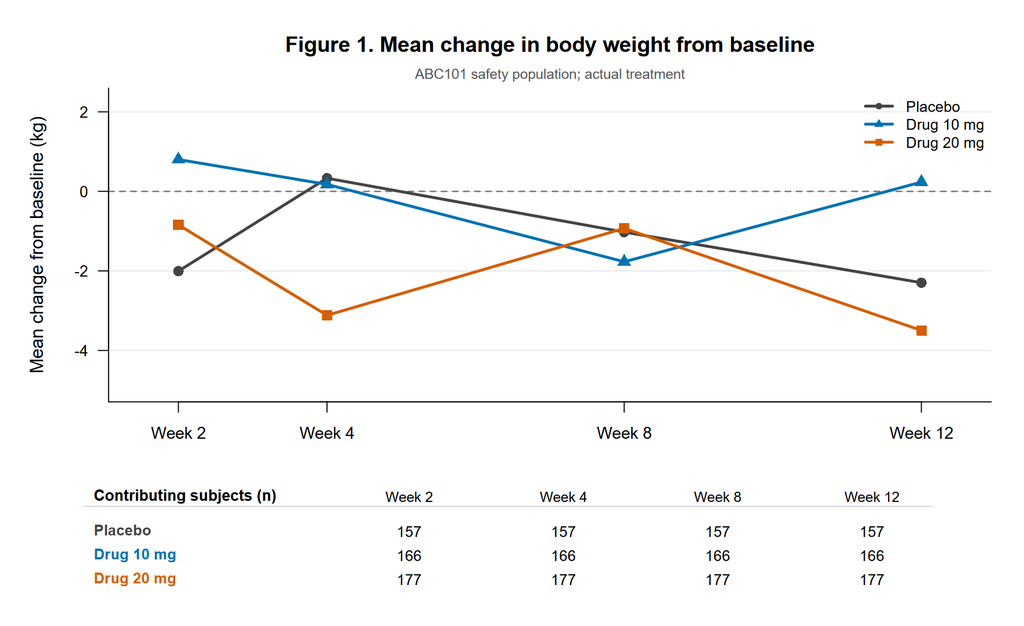

Figure 1. Mean change in body weight from baseline by visit and actual treatment.

## QC and standards screening

| Evidence | Current result | Interpretation |
| --- | --- | --- |
| SDTM cross-domain QC | PASS, **45/45** checks | Internal keys, links, dates, visits, and exposure consistency |
| ADaM QC | PASS, **52/52** checks | Internal source coverage, treatment, baseline, change, and TEAE derivations |
| Final TLF QC | PASS, **36/36** checks in the current report | Independent ADaM-based recalculation and output checks; includes optional visual attestation tied to the exact Figure 1 PNG hash |
| Dataset-specification validation | PASS, **182/182** variables over **48,000** rows | Project mapping and column-order agreement |
| Limited conformance screening | **8/8** local checks pass; **9** open or untested areas | Selected CSV/XML properties only; no published CDISC/FDA rule-workbook pass rate |

These project checks establish reproducibility and internal agreement for the current synthetic outputs. They do not certify standards conformance, medical coding, or submission readiness. The SDTM and ADaM XML files describe CSVs with `def:Context=Other`; a prior structural XSD check did not verify the selected controlled-terminology package.

## Open conformance gaps and review limits

The versioned screening findings distinguish observed gaps from untested areas. For this demonstration, the key unresolved items are:

1. **Submission transport and context:** data are CSVs, not XPT. There is no TS dataset, study tagging file, or eCTD package for FDA receipt-level checks. The assumed start date is not substantiated by an actual protocol.
2. **Terminology and coding:** the selected package-58 codelists have not been mapped or validated. `AEDECOD` is an uppercase source term, not a MedDRA-coded preferred term.
3. **Metadata and origins:** Define-XML references CSVs and lacks package-58 codelists and ADaM analysis-results metadata. No real aCRF or source system can support collection-origin claims.
4. **Formal rule execution:** the CDISC SDTM, ADaM, and Define-XML conformance-rule workbooks and FDA Business/Validator rules were not run. The eight local screening checks do not substitute for them.
5. **Clinical interpretation:** there is no SAP, endpoint rationale, predose timing evidence, adherence history, or clinical source record. The displayed differences cannot support efficacy or safety conclusions.

## Reproduce this report

From the project root, first generate and QC outputs with `Rscript run_all.R` if working from a fresh checkout. To reproduce the **current visually attested** TLF QC report, inspect the rendered Figure 1 PNG and follow the optional SHA-256 review command in the README; a normal runner execution records 35 automated TLF checks. Run `python qc/validate_conformance_v1_0.py` for the limited screening. Then render this file with `quarto render reports/ABC101_synthetic_review_v1.0.qmd --to html`. That writes `reports/ABC101_synthetic_review_v1.0.html`; the report links to files in this checkout. Regeneration may change the exact Figure 1 PNG bytes across R versions or graphics devices.